# D208_Predictive_Modeling_Task1

## Performance Assessment | D208 | Task 1: MULTIPLE REGRESSION FOR PREDICTIVE MODELING

### Name: Johan Johnson (jjo2211@wgu.edu)

### **A1. Analytical Question**

How many Gigabytes of data will a consumer use on an annual basis? Is it possible to forecast this effectively using a set of independent variables?

### **A2. Objectives and Goals:**

Stakeholders in the organization will profit if they can forecast with reasonable accuracy how many gigabytes of data a customer will use on a yearly basis. This will aid in weighing the benefits and drawbacks of increasing client data limits, providing limitless streaming capabilities, and expanding cloud computing capabilities to meet escalating bandwidth demands.

### **B1. Assumptions:**

Multiple regression is based on the following assumptions:

1. There is a linear relationship between the dependent & independent variables.
2. The independent variables shouldn't be overly correlated with other explanatory variables.
3. Observations are chosen at random and independently from the population.
4. A normal distribution with a zero mean should be found in the residuals
5. Explanatory power should rise as the number of variables increases.

### **B2. Benefits of using Python:**

Jupyter notebooks will be utilized to support this project, and Python will be used to conduct the analysis. Python is a general-purpose programming language with a focus on readability and cross-platform compatibility. When compared to other programming languages like R, it is fast and well-suited for large-scale machine learning deployment.

### **B3: Explanation on why multiple regression is an appropriate technique**

Multiple regression is an appropriate strategy for examining the research topic because when attempting to predict how much data a client will use in a given year, other predictor factors may be required to complete our picture. We will be able to analyze the degree of correlation between the dependent variables and various explanatory variables using multiple regression analysis. Multiple regression analysis can also help us understand if our target variable will have a positive or negative linear relationship with these predictor variables, and how that will affect our research question.

### **C1. Data Goals**

1. Import the dataset into Python using the read_csv command. Import appropriate libraries into Python and define x-axes and y-axes for our multiple linear regression analysis.
2. To have a better grasp of the dataset, look at the data structure.Find outliers through the use of boxplots and impute missing data with either mean, median or mode.
3. The dependent variable will be "Bandwidth_GB_Year", which will also be the continuous target variable. All binary categorical variables need to be encoded into either 1 or 0 before doing the regression analysis.
4. After defining x and y, the dataset needs to be split into a training & test set.
5. We need to train the model on the training set and forecast the test set outcomes in order to construct a model that will tell us how many gigabytes of data a customer will use in a year.
6. Continous predictor variables were used in the regression analysis.
7. Finally, these discrete ordinal predictor variables from "Item 1" to "Item 8" from the dataset were renamed according to the data dictionary inorder for the reader to better understand the features.

### **C2. Summary Statistics**

The Imported dataset included 50 columns and 10,000 records. Demographic categorical variables and user ID's were removed. All other binary categorical variables were encoded into either 1 or 0 before doing the regression analysis. There were now 33 numerical independent predictor variables and 1 dependent variable left (34 total columns). The churn dataset had already been cleaned prior to import, and there appeared to be no null or missing values in the dataset. "Bandwidth_GB_Year" and "Tenure" appear to have bimodal distributions, although "Outage sec per week" and "MonthlyCharge" appear to have normal distributions. This dataset's average age is 53.08, with a standard deviation of 20.70. The average household income is $39806.93. The maximum number of children per household is ten. The average number of gigabytes used per household was 3,392 Gigabytes per year. The target variable is "Bandwidth_GB_Year" and all other predictor variables include 'Outage_sec_perweek', 'Email', 'Contacts','Yearly_equip_failure', 'Tenure', 'MonthlyCharge', 'TimelyResponse', 'TimelyFixes', 'TimelyReplacements', 'Reliability','Options', 'RespectfulResponse', 'CourteousExchange', 'ActiveListening', 'EncodedGender', 'EncodedChurn', 'EncodedTechie', 'EncodedContract','EncodedPort_modem', 'EncodedTablet', 'EncodedInternetService','EncodedPhone', 'EncodedMultiple', 'EncodedOnlineSecurity','EncodedOnlineBackup', 'EncodedDeviceProtection', 'EncodedTechSupport','EncodedStreamingTV', 'EncodedStreamingMovies','EncodedPaperlessBilling'.

### **C3. Steps to Prepare Data**

1. Import dataset and rename survey columns/variables to make them more clearly recognizable
2. Understand data structure and checkout summary statistics
3. Remove all demographic categorical factors as well as any other columns that are irrelevant to the multi regression analysis.
4. Look for any missing values and impute missing values with mean, mode or median.
5. Convert binary categorical data points to numerical values
6. Use histograms to analyze univariate visualizations and scatterplots to examine bivariate visuals.
7. The produced dataset will be exported and made accessible as "newchurn.csv" in the form of a spreadsheet.

```python
#Import Libraries
import numpy as np
import pandas as pd
import seaborn as sns
from pandas import Series, DataFrame
import matplotlib.pyplot as plt
%matplotlib inline

import pylab
from pylab import rcParams
import statsmodels.api as sm
import statistics
from scipy import stats

import sklearn
from sklearn import preprocessing
from sklearn.linear_model import LinearRegression
from sklearn.model_selection import train_test_split
from sklearn import metrics
from sklearn.metrics import classification_report
from sklearn.metrics import mean_squared_error, r2_score, mean_absolute_error
import warnings
warnings.filterwarnings('ignore')
```

```python
#Import dataset by using the read_csv command
churn = pd.read_csv('churn_clean.csv')
```

```python
#Rename survey columns/variables
churn.rename(columns = {'Item1':'TimelyResponse','Item2':'TimelyFixes',
'Item3':'TimelyReplacements','Item4':'Reliability','Item5':'Options',
'Item6':'RespectfulResponse','Item7':'CourteousExchange','Item8':'ActiveListening'},
inplace=True)
```

```python
#List of columns in the churn dataset
df = churn.columns
print(df)
```

[output not shown]

```python
#Drop demographic categorical variables
churn= churn.drop(columns=['CaseOrder', 'Customer_id', 'Interaction', 'UID', 'City',
'State', 'County', 'Zip', 'Lat', 'Lng', 'Population', 'Area', 'TimeZone', 'Job', 'Marital', 'PaymentMethod'])
```

```python
churn.describe()
```

|  | Children | Age | Income | Outage_sec_perweek | Email | Contacts | Yearly_equip_failure | Tenure | MonthlyCharge | Bandwidth_GB_Year | TimelyResponse | TimelyFixes | TimelyReplacements | Reliability | Options | RespectfulResponse | CourteousExchange | ActiveListening |
| --- | --- | --- | --- | --- | --- | --- | --- | --- | --- | --- | --- | --- | --- | --- | --- | --- | --- | --- |
| count | 10000.0000 | 10000.000000 | 10000.000000 | 10000.000000 | 10000.000000 | 10000.000000 | 10000.000000 | 10000.000000 | 10000.000000 | 10000.000000 | 10000.000000 | 10000.000000 | 10000.000000 | 10000.000000 | 10000.000000 | 10000.000000 | 10000.000000 | 10000.000000 |
| mean | 2.0877 | 53.078400 | 39806.926771 | 10.001848 | 12.016000 | 0.994200 | 0.398000 | 34.526188 | 172.624816 | 3392.341550 | 3.490800 | 3.505100 | 3.487000 | 3.497500 | 3.492900 | 3.497300 | 3.509500 | 3.495600 |
| std | 2.1472 | 20.698882 | 28199.916702 | 2.976019 | 3.025898 | 0.988466 | 0.635953 | 26.443063 | 42.943094 | 2185.294852 | 1.037797 | 1.034641 | 1.027977 | 1.025816 | 1.024819 | 1.033586 | 1.028502 | 1.028633 |
| min | 0.0000 | 18.000000 | 348.670000 | 0.099747 | 1.000000 | 0.000000 | 0.000000 | 1.000259 | 79.978860 | 155.506715 | 1.000000 | 1.000000 | 1.000000 | 1.000000 | 1.000000 | 1.000000 | 1.000000 | 1.000000 |
| 25% | 0.0000 | 35.000000 | 19224.717500 | 8.018214 | 10.000000 | 0.000000 | 0.000000 | 7.917694 | 139.979239 | 1236.470827 | 3.000000 | 3.000000 | 3.000000 | 3.000000 | 3.000000 | 3.000000 | 3.000000 | 3.000000 |
| 50% | 1.0000 | 53.000000 | 33170.605000 | 10.018560 | 12.000000 | 1.000000 | 0.000000 | 35.430507 | 167.484700 | 3279.536903 | 3.000000 | 4.000000 | 3.000000 | 3.000000 | 3.000000 | 3.000000 | 4.000000 | 3.000000 |
| 75% | 3.0000 | 71.000000 | 53246.170000 | 11.969485 | 14.000000 | 2.000000 | 1.000000 | 61.479795 | 200.734725 | 5586.141370 | 4.000000 | 4.000000 | 4.000000 | 4.000000 | 4.000000 | 4.000000 | 4.000000 | 4.000000 |
| max | 10.0000 | 89.000000 | 258900.700000 | 21.207230 | 23.000000 | 7.000000 | 6.000000 | 71.999280 | 290.160419 | 7158.981530 | 7.000000 | 7.000000 | 8.000000 | 7.000000 | 7.000000 | 8.000000 | 7.000000 | 8.000000 |

```python
#Check to see if there are any null or missing values
#Looks like there are no null values since the churn dataset is cleaned prior
anyvalues= churn.isnull().sum()
print(anyvalues)
```

[output not shown]

```python
#Encode categorical variables into numerical values
churn['EncodedGender'] = [1 if i == 'Male' else 0 for  i in churn['Gender']]
churn['EncodedChurn'] = [1 if i == 'Yes' else 0 for i in churn['Churn']]
churn['EncodedTechie'] = [1 if i == 'Yes' else 0 for i in churn['Techie']]
churn['EncodedContract'] = [1 if i == 'One year' else 0 for i in churn['Contract']]
churn['EncodedPort_modem'] = [1 if i == 'Yes' else 0 for i in churn['Port_modem']]
churn['EncodedTablet'] = [1 if i == 'Yes' else 0 for i in churn['Tablet']]
churn['EncodedInternetService'] = [1 if i == 'DSL' else 0 for i in churn['InternetService']]
churn['EncodedPhone'] = [1 if i == 'Yes' else 0 for i in churn['Phone']]
churn['EncodedMultiple'] = [1 if i == 'Yes' else 0 for i in churn['Multiple']]
churn['EncodedOnlineSecurity'] = [1 if i == 'Yes' else 0 for i in churn['OnlineSecurity']]
churn['EncodedOnlineBackup'] = [1 if i == 'Yes' else 0 for i in churn['OnlineBackup']]
churn['EncodedDeviceProtection'] = [1 if i == 'Yes' else 0 for i in churn['DeviceProtection']]
churn['EncodedTechSupport'] = [1 if i == 'Yes' else 0 for i in churn['TechSupport']]
churn['EncodedStreamingTV'] = [1 if i == 'Yes' else 0 for i in churn['StreamingTV']]
churn['EncodedStreamingMovies'] = [1 if i == 'Yes' else 0 for i in churn['StreamingMovies']]
churn['EncodedPaperlessBilling'] = [1 if i == 'Yes' else 0 for i in churn['PaperlessBilling']]
```

```python
# Drop ORIGINAL categorical features from dataframe
churn= churn.drop(columns=['Gender', 'Churn', 'Techie', 'Contract', 'Port_modem', 'Tablet', 'InternetService', 'Phone', 'Multiple', 'OnlineSecurity',
'OnlineBackup', 'DeviceProtection', 'TechSupport', 'StreamingTV', 'StreamingMovies', 'PaperlessBilling'])
churn.describe()
```

[output not shown]

```python
#Place "Bandwith_GB_Year" at the end of the dataframe
churn = churn[['Children', 'Age', 'Income', 'Outage_sec_perweek', 'Email', 'Contacts','Yearly_equip_failure', 'Tenure', 'MonthlyCharge',
'TimelyResponse', 'TimelyFixes', 'TimelyReplacements', 'Reliability',
'Options', 'RespectfulResponse', 'CourteousExchange', 'ActiveListening',
'EncodedGender', 'EncodedChurn', 'EncodedTechie', 'EncodedContract',
'EncodedPort_modem', 'EncodedTablet', 'EncodedInternetService',
'EncodedPhone', 'EncodedMultiple', 'EncodedOnlineSecurity',
'EncodedOnlineBackup', 'EncodedDeviceProtection', 'EncodedTechSupport',
'EncodedStreamingTV', 'EncodedStreamingMovies',
'EncodedPaperlessBilling', 'Bandwidth_GB_Year']]
```

```python
churn.head()
```

|  | Children | Age | Income | Outage_sec_perweek | Email | Contacts | Yearly_equip_failure | Tenure | MonthlyCharge | TimelyResponse | ... | EncodedPhone | EncodedMultiple | EncodedOnlineSecurity | EncodedOnlineBackup | EncodedDeviceProtection | EncodedTechSupport | EncodedStreamingTV | EncodedStreamingMovies | EncodedPaperlessBilling | Bandwidth_GB_Year |
| --- | --- | --- | --- | --- | --- | --- | --- | --- | --- | --- | --- | --- | --- | --- | --- | --- | --- | --- | --- | --- | --- |
| 0 | 0 | 68 | 28561.99 | 7.978323 | 10 | 0 | 1 | 6.795513 | 172.455519 | 5 | ... | 1 | 0 | 1 | 1 | 0 | 0 | 0 | 1 | 1 | 904.536110 |
| 1 | 1 | 27 | 21704.77 | 11.699080 | 12 | 0 | 1 | 1.156681 | 242.632554 | 3 | ... | 1 | 1 | 1 | 0 | 0 | 0 | 1 | 1 | 1 | 800.982766 |
| 2 | 4 | 50 | 9609.57 | 10.752800 | 9 | 0 | 1 | 15.754144 | 159.947583 | 4 | ... | 1 | 1 | 0 | 0 | 0 | 0 | 0 | 1 | 1 | 2054.706961 |
| 3 | 1 | 48 | 18925.23 | 14.913540 | 15 | 2 | 0 | 17.087227 | 119.956840 | 4 | ... | 1 | 0 | 1 | 0 | 0 | 0 | 1 | 0 | 1 | 2164.579412 |
| 4 | 0 | 83 | 40074.19 | 8.147417 | 16 | 2 | 1 | 1.670972 | 149.948316 | 4 | ... | 0 | 0 | 0 | 0 | 0 | 1 | 1 | 0 | 0 | 271.493436 |

5 rows × 34 columns

### **C4. Univariate and Bivariate Visualizations**

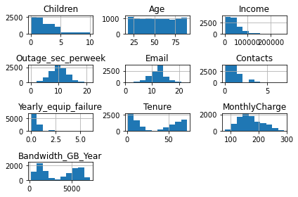

```python
#univariate stats (Visualizations for each continous variables)
churn[['Children', 'Age', 'Income', 'Outage_sec_perweek', 'Email', 'Contacts',
'Yearly_equip_failure', 'Tenure', 'MonthlyCharge','Bandwidth_GB_Year']].hist()
plt.tight_layout()
```

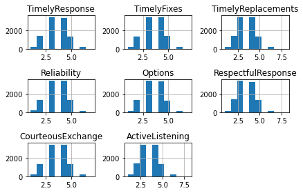

```python
churn[['TimelyResponse', 'TimelyFixes', 'TimelyReplacements', 'Reliability',
'Options', 'RespectfulResponse', 'CourteousExchange', 'ActiveListening']].hist()
plt.tight_layout()
```

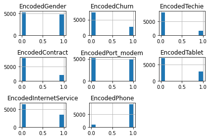

```python
#Univariate stats (visualizations for encoded categorical variables)
churn[['EncodedGender', 'EncodedChurn', 'EncodedTechie', 'EncodedContract',
'EncodedPort_modem', 'EncodedTablet', 'EncodedInternetService',
'EncodedPhone']].hist()
plt.tight_layout()
```

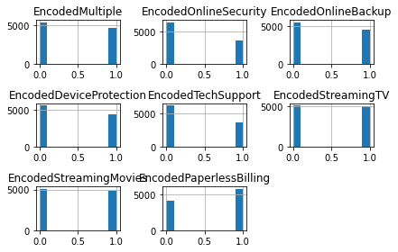

```python
churn[['EncodedMultiple', 'EncodedOnlineSecurity',
'EncodedOnlineBackup', 'EncodedDeviceProtection', 'EncodedTechSupport', 'EncodedStreamingTV', 'EncodedStreamingMovies',
'EncodedPaperlessBilling']].hist()
plt.tight_layout()
```

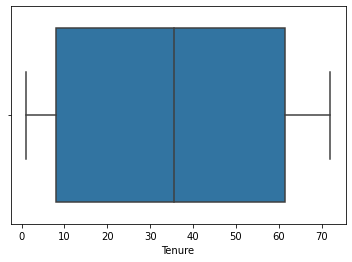

```python
#Checking to see if there are any outliers by using boxplot
sns.boxplot('Tenure', data= churn)
plt.show()
```

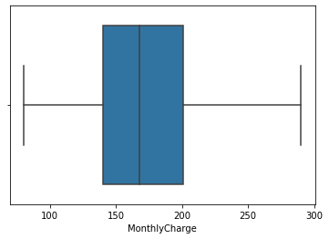

```python
sns.boxplot('MonthlyCharge', data = churn)
plt.show()
```

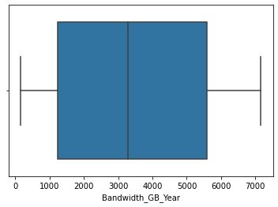

```python
sns.boxplot('Bandwidth_GB_Year', data = churn)
plt.show()
```

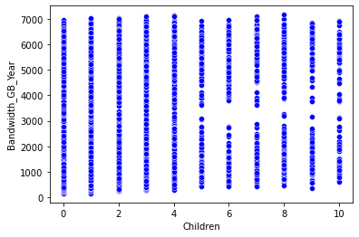

```python
#bivariate stats
sns.scatterplot(x=churn['Children'], y=churn['Bandwidth_GB_Year'], color='blue')
plt.show();
```

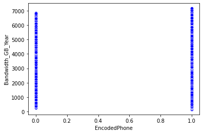

```python
sns.scatterplot(x=churn['EncodedPhone'], y=churn['Bandwidth_GB_Year'], color='blue')
plt.show();
```

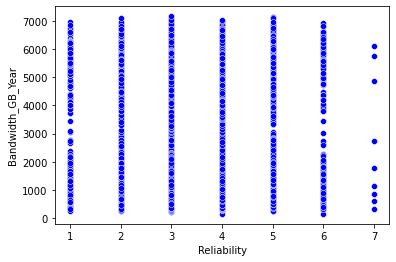

```python
sns.scatterplot(x=churn['Reliability'], y=churn['Bandwidth_GB_Year'], color='blue')
plt.show();
```

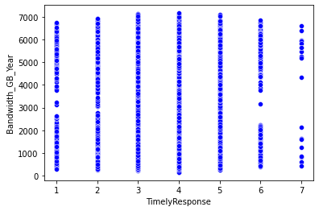

```python
sns.scatterplot(x=churn['TimelyResponse'], y=churn['Bandwidth_GB_Year'], color='blue')
plt.show();
```

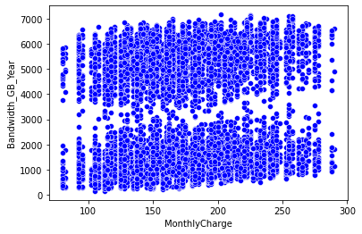

```python
sns.scatterplot(x=churn['MonthlyCharge'], y=churn['Bandwidth_GB_Year'], color='blue')
plt.show();
```

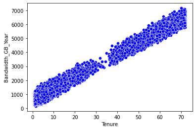

```python
sns.scatterplot(x=churn['Tenure'], y=churn['Bandwidth_GB_Year'], color='blue')
plt.show();
```

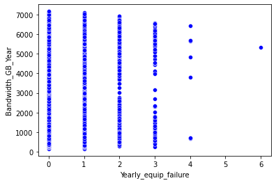

```python
sns.scatterplot(x=churn['Yearly_equip_failure'], y=churn['Bandwidth_GB_Year'], color='blue')
plt.show();
```

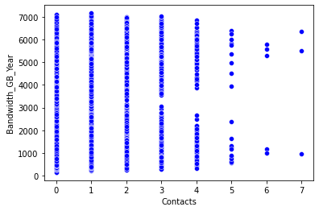

```python
sns.scatterplot(x=churn['Contacts'], y=churn['Bandwidth_GB_Year'], color='blue')
plt.show();
```

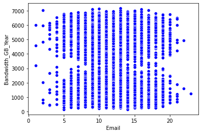

```python
sns.scatterplot(x=churn['Email'], y=churn['Bandwidth_GB_Year'], color='blue')
plt.show();
```

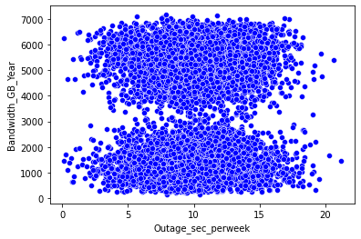

```python
sns.scatterplot(x=churn['Outage_sec_perweek'], y=churn['Bandwidth_GB_Year'], color='blue')
plt.show();
```

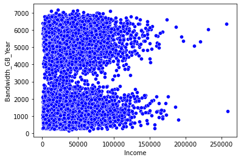

```python
sns.scatterplot(x=churn['Income'], y=churn['Bandwidth_GB_Year'], color='blue')
plt.show();
```

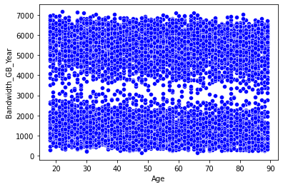

```python
sns.scatterplot(x=churn['Age'], y=churn['Bandwidth_GB_Year'], color='blue')
plt.show();
```

### **C5. Prepared Dataset**

```python
churn.to_csv('newchurn.csv')
newchurn = pd.read_csv('newchurn.csv')
```

```python
newchurn.shape
```

```
(10000, 35)
```

### **D1. Initial Regression Model**

```python
#OLS Regression Results (Dummy variables are not included)

newchurn['intercept'] = 1
lm_bandwidth = sm.OLS(newchurn['Bandwidth_GB_Year'], newchurn[['Children', 'Age', 'Income',
'Outage_sec_perweek', 'Email', 'Contacts','Yearly_equip_failure', 'Tenure', 'MonthlyCharge',
'TimelyResponse', 'TimelyFixes', 'TimelyReplacements', 'Reliability',
'Options', 'RespectfulResponse', 'CourteousExchange', 'ActiveListening', 'intercept']]).fit()

print(lm_bandwidth.summary())
```

```
                            OLS Regression Results
==============================================================================
Dep. Variable:      Bandwidth_GB_Year   R-squared:                       0.989
Model:                            OLS   Adj. R-squared:                  0.989
Method:                 Least Squares   F-statistic:                 5.329e+04
Date:                Mon, 18 Oct 2021   Prob (F-statistic):               0.00
Time:                        17:43:26   Log-Likelihood:                -68489.
No. Observations:               10000   AIC:                         1.370e+05
Df Residuals:                    9982   BIC:                         1.371e+05
Df Model:                          17
Covariance Type:            nonrobust
========================================================================================
                           coef    std err          t      P>|t|      [0.025      0.975]
----------------------------------------------------------------------------------------
Children                30.9275      1.065     29.050      0.000      28.841      33.014
Age                     -3.3206      0.110    -30.065      0.000      -3.537      -3.104
Income                9.976e-05    8.1e-05      1.231      0.218   -5.91e-05       0.000
Outage_sec_perweek      -0.3501      0.768     -0.456      0.649      -1.856       1.156
Email                   -0.2792      0.755     -0.370      0.712      -1.759       1.201
Contacts                 2.9707      2.312      1.285      0.199      -1.562       7.503
Yearly_equip_failure     0.9080      3.593      0.253      0.801      -6.136       7.952
Tenure                  82.0113      0.086    948.882      0.000      81.842      82.181
MonthlyCharge            3.2768      0.053     61.585      0.000       3.173       3.381
TimelyResponse          -8.8961      3.271     -2.720      0.007     -15.308      -2.484
TimelyFixes              3.4660      3.064      1.131      0.258      -2.541       9.473
TimelyReplacements      -0.1771      2.812     -0.063      0.950      -5.690       5.335
Reliability             -0.2697      2.515     -0.107      0.915      -5.199       4.659
Options                  2.7199      2.611      1.042      0.298      -2.398       7.838
RespectfulResponse       1.7157      2.689      0.638      0.523      -3.554       6.986
CourteousExchange       -1.3482      2.543     -0.530      0.596      -6.333       3.637
ActiveListening          5.7844      2.420      2.390      0.017       1.040      10.529
intercept               95.8754     26.146      3.667      0.000      44.624     147.127
==============================================================================
Omnibus:                    12280.983   Durbin-Watson:                   1.979
Prob(Omnibus):                  0.000   Jarque-Bera (JB):              968.853
Skew:                           0.449   Prob(JB):                    4.13e-211
Kurtosis:                       1.768   Cond. No.                     5.60e+05
==============================================================================

Notes:
[1] Standard Errors assume that the covariance matrix of the errors is correctly specified.
[2] The condition number is large, 5.6e+05. This might indicate that there are
strong multicollinearity or other numerical problems.
```

```python
#Define x and y
x = newchurn.drop(['Bandwidth_GB_Year'], axis = 1).values
y = newchurn['Bandwidth_GB_Year'].values
```

```python
print(x)
```

```
[[0.000e+00 0.000e+00 6.800e+01 ... 1.000e+00 1.000e+00 1.000e+00]
 [1.000e+00 1.000e+00 2.700e+01 ... 1.000e+00 1.000e+00 1.000e+00]
 [2.000e+00 4.000e+00 5.000e+01 ... 1.000e+00 1.000e+00 1.000e+00]
 ...
 [9.997e+03 1.000e+00 4.800e+01 ... 0.000e+00 1.000e+00 1.000e+00]
 [9.998e+03 1.000e+00 3.900e+01 ... 1.000e+00 1.000e+00 1.000e+00]
 [9.999e+03 1.000e+00 2.800e+01 ... 1.000e+00 1.000e+00 1.000e+00]]
```

```python
print(y)
```

```
[ 904.5361102  800.9827661 2054.706961  ... 4159.305799  6468.456752
 5857.586167 ]
```

```python
#Split the dataset in training set and test set
x_train, x_test, y_train, y_test = train_test_split(x,y,test_size = 0.3, random_state = 0)
```

```python
regr =LinearRegression()
regr.fit(x_train, y_train)
```

```
LinearRegression()
```

```python
y_pred = regr.predict(x_test)
print(y_pred)
```

```
[5605.38917596  543.72609356 1428.87782996 ... 6087.44992665 3764.82468677
 5645.08329151]
```

```python
#grab the intercept
intercept = regr.intercept_
intercept
```

```
49.574001160393436
```

```python
print("The intercept for our model is {:.4}".format(intercept))
print('-'*100)
```

```
The intercept for our model is 49.57
----------------------------------------------------------------------------------------------------
```

```python
#R2 Score
r2_score(y_test, y_pred)
```

```
0.9998906499377737
```

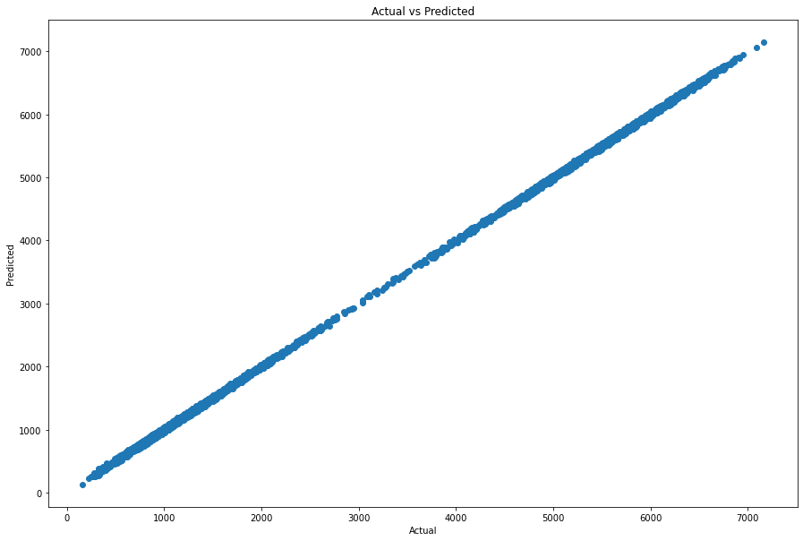

```python
#Actual vs Predicted Graph
plt.figure(figsize = (15,10))
plt.scatter(y_test, y_pred)
plt.xlabel('Actual')
plt.ylabel('Predicted')
plt.title('Actual vs Predicted')
```

```python
#All predictor variables (Including the dummy variables)
newchurn['intercept'] = 1
lm_bandwidth = sm.OLS(newchurn['Bandwidth_GB_Year'], newchurn[['Children', 'Age', 'Income',
'Outage_sec_perweek', 'Email', 'Contacts','Yearly_equip_failure', 'Tenure', 'MonthlyCharge',
'TimelyResponse', 'TimelyFixes', 'TimelyReplacements', 'Reliability',
'Options', 'RespectfulResponse', 'CourteousExchange', 'ActiveListening',
'EncodedGender', 'EncodedChurn', 'EncodedTechie', 'EncodedContract',
'EncodedPort_modem', 'EncodedTablet', 'EncodedInternetService',
'EncodedPhone', 'EncodedMultiple', 'EncodedOnlineSecurity',
'EncodedOnlineBackup', 'EncodedDeviceProtection', 'EncodedTechSupport',
'EncodedStreamingTV', 'EncodedStreamingMovies',
'EncodedPaperlessBilling', 'intercept']]).fit()

print(lm_bandwidth.summary())
```

```
                            OLS Regression Results
==============================================================================
Dep. Variable:      Bandwidth_GB_Year   R-squared:                       1.000
Model:                            OLS   Adj. R-squared:                  1.000
Method:                 Least Squares   F-statistic:                 2.814e+06
Date:                Mon, 18 Oct 2021   Prob (F-statistic):               0.00
Time:                        17:43:28   Log-Likelihood:                -45386.
No. Observations:               10000   AIC:                         9.084e+04
Df Residuals:                    9966   BIC:                         9.108e+04
Df Model:                          33
Covariance Type:            nonrobust
===========================================================================================
                              coef    std err          t      P>|t|      [0.025      0.975]
-------------------------------------------------------------------------------------------
Children                   30.8198      0.106    291.343      0.000      30.612      31.027
Age                        -3.2663      0.011   -297.598      0.000      -3.288      -3.245
Income                   6.767e-06   8.06e-06      0.840      0.401   -9.03e-06    2.26e-05
Outage_sec_perweek         -0.0226      0.076     -0.296      0.768      -0.172       0.127
Email                      -0.0025      0.075     -0.033      0.974      -0.150       0.145
Contacts                   -0.2026      0.230     -0.882      0.378      -0.653       0.248
Yearly_equip_failure       -0.3415      0.357     -0.956      0.339      -1.041       0.358
Tenure                     81.9796      0.010   8018.705      0.000      81.960      82.000
MonthlyCharge               0.9556      0.015     63.793      0.000       0.926       0.985
TimelyResponse             -0.7568      0.325     -2.326      0.020      -1.394      -0.119
TimelyFixes                 0.5261      0.305      1.726      0.084      -0.071       1.124
TimelyReplacements          0.2161      0.280      0.773      0.439      -0.332       0.764
Reliability                 0.1638      0.250      0.655      0.512      -0.326       0.654
Options                     0.2169      0.260      0.836      0.403      -0.292       0.726
RespectfulResponse         -0.1938      0.267     -0.726      0.468      -0.718       0.330
CourteousExchange           0.1443      0.253      0.571      0.568      -0.351       0.640
ActiveListening            -0.1796      0.240     -0.747      0.455      -0.651       0.292
EncodedGender              65.4513      0.455    143.734      0.000      64.559      66.344
EncodedChurn                6.0353      0.683      8.830      0.000       4.696       7.375
EncodedTechie               0.3044      0.609      0.499      0.617      -0.890       1.499
EncodedContract             1.7608      0.568      3.099      0.002       0.647       2.874
EncodedPort_modem          -0.7374      0.454     -1.623      0.105      -1.628       0.153
EncodedTablet              -0.2041      0.496     -0.411      0.681      -1.177       0.769
EncodedInternetService    422.4050      0.502    841.769      0.000     421.421     423.389
EncodedPhone               -0.6602      0.782     -0.845      0.398      -2.192       0.872
EncodedMultiple            39.7092      0.674     58.897      0.000      38.388      41.031
EncodedOnlineSecurity      72.9126      0.476    153.035      0.000      71.979      73.847
EncodedOnlineBackup        72.0396      0.568    126.904      0.000      70.927      73.152
EncodedDeviceProtection    72.9263      0.495    147.376      0.000      71.956      73.896
EncodedTechSupport         -7.1288      0.503    -14.165      0.000      -8.115      -6.142
EncodedStreamingTV        186.5279      0.782    238.550      0.000     184.995     188.061
EncodedStreamingMovies    158.5530      0.913    173.664      0.000     156.763     160.343
EncodedPaperlessBilling     0.4836      0.462      1.048      0.295      -0.421       1.388
intercept                  51.5574      2.981     17.295      0.000      45.714      57.401
==============================================================================
Omnibus:                      456.854   Durbin-Watson:                   1.984
Prob(Omnibus):                  0.000   Jarque-Bera (JB):              201.159
Skew:                           0.106   Prob(JB):                     2.08e-44
Kurtosis:                       2.338   Cond. No.                     6.54e+05
==============================================================================

Notes:
[1] Standard Errors assume that the covariance matrix of the errors is correctly specified.
[2] The condition number is large, 6.54e+05. This might indicate that there are
strong multicollinearity or other numerical problems.
```

## Initial MLR Model Equation based on the OLS Regression Results

y = 51.6 + 30.82*X<sub>1</sub> + -3.27*X<sub>2</sub> + 0*X<sub>3</sub> + -0.0226*X<sub>4</sub> + -0.0025*X<sub>5</sub> + -0.2026*X<sub>6</sub>+ -0.3415*X<sub>7</sub> + 81.98*X<sub>8</sub> + 0.96*X<sub>9</sub> + -0.76*X<sub>10</sub> + 0.53*X<sub>11</sub> + 0.22*X<sub>12</sub> + 0.164*X<sub>13</sub>+ .22*X<sub>14</sub> + -0.19*X<sub>15</sub> + 0.1443*X<sub>16</sub> + -0.1796*X<sub>17</sub> + 65.45*X<sub>18</sub> + 6.04*X<sub>19</sub> + 0.3044*X<sub>20</sub> + 1.76*X<sub>21</sub> + -0.74*X<sub>22</sub> + -0.20*X<sub>23</sub> + 422.41*X<sub>24</sub> + -0.66*X<sub>25</sub> + 39.71*X<sub>26</sub> + 72.91*X<sub>27</sub> + 72.04*X<sub>28</sub> + 72.93*X<sub>29</sub> + -7.13*X<sub>30</sub> + 186.53*X<sub>31</sub> + 158.5530*X<sub>32</sub> + 0.48*X<sub>33</sub>

### **D2. Justification for Model Reduction**

The most sophisticated model isn't always the best. Including variables that aren't clearly significant might sometimes impair the accuracy of forecasts. The full model is commonly referred to as the initial model because it included all known explanatory variables. We want to find a smaller model that is preferable because the full model is not the best model. P values from the OLS regression results provides helpful information. P-values can be used to assess hypotheses of the following form: The null hypothesis (H_o) is that beta_i **equals zero** when the other variables are included in the model. The alternative hypothesis (H_a) is that beta_i is **not equal** to zero when the other variables are included in the model. One model selection strategy is the **backward-elimination strategy**. The approach begins with a model that incorporates all possible predictor variables. Variables are excluded from the model ONE AT A TIME until only those with statistically significant p values remain (until the P values are smaller than the alpha value) (0.05)

1. Email has the highest p value. Delete the "Email" column and refit the model
2. Other variables with p values greater than the alpha value (0.05) needs to be removed.
3. Other variables that were eliminated include 'Income', 'Outage_sec_perweek', 'Contacts','Yearly_equip_failure', 'TimelyFixes', 'TimelyReplacements', 'Reliability', 'Options', 'RespectfulResponse', 'CourteousExchange', 'ActiveListening', 'EncodedTechie', 'EncodedPort_modem', 'EncodedTablet', 'EncodedPhone', 'EncodedPaperlessBilling'
4. Refit the model and see if there are any more p values that are greater than the alpha value.
5. P value for "TimelyResponse" is 0.093. Remove the "TimelyResponse" variable.
6. Run the seaborn heatmap to see any correlation

### **D3. Reduced Regression Model**

```python
#Includes the refined predictor variables.
newchurn['intercept'] = 1
lm_bandwidth = sm.OLS(newchurn['Bandwidth_GB_Year'], newchurn[['Children', 'Age', 'Tenure', 'MonthlyCharge',
'TimelyResponse',
'EncodedGender', 'EncodedChurn', 'EncodedContract', 'EncodedInternetService',
'EncodedMultiple', 'EncodedOnlineSecurity',
'EncodedOnlineBackup', 'EncodedDeviceProtection', 'EncodedTechSupport',
'EncodedStreamingTV', 'EncodedStreamingMovies', 'intercept']]).fit()

print(lm_bandwidth.summary())
```

```
                            OLS Regression Results
==============================================================================
Dep. Variable:      Bandwidth_GB_Year   R-squared:                       1.000
Model:                            OLS   Adj. R-squared:                  1.000
Method:                 Least Squares   F-statistic:                 5.805e+06
Date:                Mon, 18 Oct 2021   Prob (F-statistic):               0.00
Time:                        17:43:28   Log-Likelihood:                -45393.
No. Observations:               10000   AIC:                         9.082e+04
Df Residuals:                    9983   BIC:                         9.094e+04
Df Model:                          16
Covariance Type:            nonrobust
===========================================================================================
                              coef    std err          t      P>|t|      [0.025      0.975]
-------------------------------------------------------------------------------------------
Children                   30.8211      0.106    291.597      0.000      30.614      31.028
Age                        -3.2667      0.011   -297.870      0.000      -3.288      -3.245
Tenure                     81.9801      0.010   8030.318      0.000      81.960      82.000
MonthlyCharge               0.9565      0.015     63.906      0.000       0.927       0.986
TimelyResponse             -0.3670      0.219     -1.678      0.093      -0.796       0.062
EncodedGender              65.4112      0.455    143.883      0.000      64.520      66.302
EncodedChurn                6.0652      0.681      8.912      0.000       4.731       7.399
EncodedContract             1.7463      0.567      3.078      0.002       0.634       2.859
EncodedInternetService    422.4168      0.501    842.781      0.000     421.434     423.399
EncodedMultiple            39.6716      0.673     58.939      0.000      38.352      40.991
EncodedOnlineSecurity      72.8885      0.476    153.166      0.000      71.956      73.821
EncodedOnlineBackup        72.0417      0.567    126.964      0.000      70.929      73.154
EncodedDeviceProtection    72.9402      0.494    147.558      0.000      71.971      73.909
EncodedTechSupport         -7.1247      0.503    -14.170      0.000      -8.110      -6.139
EncodedStreamingTV        186.4585      0.781    238.733      0.000     184.928     187.989
EncodedStreamingMovies    158.4863      0.912    173.824      0.000     156.699     160.274
intercept                  52.2787      1.834     28.507      0.000      48.684      55.874
==============================================================================
Omnibus:                      455.552   Durbin-Watson:                   1.985
Prob(Omnibus):                  0.000   Jarque-Bera (JB):              201.041
Skew:                           0.106   Prob(JB):                     2.21e-44
Kurtosis:                       2.339   Cond. No.                     1.71e+03
==============================================================================

Notes:
[1] Standard Errors assume that the covariance matrix of the errors is correctly specified.
[2] The condition number is large, 1.71e+03. This might indicate that there are
strong multicollinearity or other numerical problems.
```

```python
#Removed the TimelyResponse variable.
newchurn['intercept'] = 1
lm_bandwidth_reduced = sm.OLS(newchurn['Bandwidth_GB_Year'], newchurn[['Children', 'Age', 'Tenure', 'MonthlyCharge',
'EncodedGender', 'EncodedChurn', 'EncodedContract', 'EncodedInternetService',
'EncodedMultiple', 'EncodedOnlineSecurity',
'EncodedOnlineBackup', 'EncodedDeviceProtection', 'EncodedTechSupport',
'EncodedStreamingTV', 'EncodedStreamingMovies', 'intercept']]).fit()

print(lm_bandwidth_reduced.summary())
```

```
                            OLS Regression Results
==============================================================================
Dep. Variable:      Bandwidth_GB_Year   R-squared:                       1.000
Model:                            OLS   Adj. R-squared:                  1.000
Method:                 Least Squares   F-statistic:                 6.191e+06
Date:                Mon, 18 Oct 2021   Prob (F-statistic):               0.00
Time:                        17:43:28   Log-Likelihood:                -45394.
No. Observations:               10000   AIC:                         9.082e+04
Df Residuals:                    9984   BIC:                         9.094e+04
Df Model:                          15
Covariance Type:            nonrobust
===========================================================================================
                              coef    std err          t      P>|t|      [0.025      0.975]
-------------------------------------------------------------------------------------------
Children                   30.8190      0.106    291.570      0.000      30.612      31.026
Age                        -3.2666      0.011   -297.839      0.000      -3.288      -3.245
Tenure                     81.9803      0.010   8030.093      0.000      81.960      82.000
MonthlyCharge               0.9560      0.015     63.880      0.000       0.927       0.985
EncodedGender              65.4266      0.455    143.932      0.000      64.536      66.318
EncodedChurn                6.0780      0.681      8.931      0.000       4.744       7.412
EncodedContract             1.7431      0.568      3.071      0.002       0.631       2.855
EncodedInternetService    422.4215      0.501    842.728      0.000     421.439     423.404
EncodedMultiple            39.6778      0.673     58.943      0.000      38.358      40.997
EncodedOnlineSecurity      72.8900      0.476    153.155      0.000      71.957      73.823
EncodedOnlineBackup        72.0561      0.567    126.992      0.000      70.944      73.168
EncodedDeviceProtection    72.9436      0.494    147.553      0.000      71.975      73.913
EncodedTechSupport         -7.1416      0.503    -14.205      0.000      -8.127      -6.156
EncodedStreamingTV        186.4723      0.781    238.742      0.000     184.941     188.003
EncodedStreamingMovies    158.5144      0.912    173.868      0.000     156.727     160.301
intercept                  51.0327      1.677     30.431      0.000      47.745      54.320
==============================================================================
Omnibus:                      452.852   Durbin-Watson:                   1.985
Prob(Omnibus):                  0.000   Jarque-Bera (JB):              200.471
Skew:                           0.107   Prob(JB):                     2.94e-44
Kurtosis:                       2.340   Cond. No.                     1.63e+03
==============================================================================

Notes:
[1] Standard Errors assume that the covariance matrix of the errors is correctly specified.
[2] The condition number is large, 1.63e+03. This might indicate that there are
strong multicollinearity or other numerical problems.
```

**Even after removing all those other predictor variables, our model is still doing a good job approximating the regression predictions.**

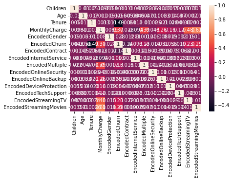

```python
#Seaborn heatmap
churn_bivariation = newchurn[['Children', 'Age', 'Tenure', 'MonthlyCharge',
'EncodedGender', 'EncodedChurn', 'EncodedContract', 'EncodedInternetService',
'EncodedMultiple', 'EncodedOnlineSecurity',
'EncodedOnlineBackup', 'EncodedDeviceProtection', 'EncodedTechSupport',
'EncodedStreamingTV', 'EncodedStreamingMovies']]
sns.heatmap(churn_bivariation.corr(), annot=True)
plt.show()
```

Now with 15 independent/explanatory variables.

### **E1. Residual Plot**

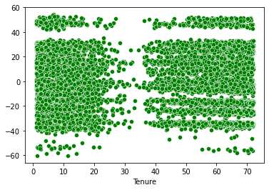

```python
churns = pd.read_csv('newchurn.csv')
churns['intercept'] = 1
residuals = churns['Bandwidth_GB_Year'] - lm_bandwidth_reduced.predict(churns[['Children','Age', 'Tenure', 'MonthlyCharge',
'EncodedGender', 'EncodedChurn', 'EncodedContract', 'EncodedInternetService',
'EncodedMultiple', 'EncodedOnlineSecurity',
'EncodedOnlineBackup', 'EncodedDeviceProtection', 'EncodedTechSupport',
'EncodedStreamingTV', 'EncodedStreamingMovies', 'intercept']])
sns.scatterplot(x=churns['Tenure'],y=residuals,color='green')
```

### **E2. Output/Calculations**

See the calculations and outputs listed above.

### **E3. Code**

See code listed above.

### **F1. Summarize Findings and assumptions**

F1.2: The sign of the coefficient indicates whether each independent or dependent variable have a positive or negative relationship. A positive coefficient indicates that the mean of the dependent variable tends to rise when the value of the independent variable rises. A negative coefficient indicates that the dependent variable tends to drop as the independent variable increases. When the independent variable is modified by one unit while the other variables in the model remain constant, the coefficient value reflects how much the mean of the dependent variable changes. According to the coefficients, for every 1 unit of:

- Children - Bandwith gigabytes per year will increase by 30.82 units
- Age - Bandwith gigabytes per year will decrease by 3.27 units
- Tenure - Bandwith gigabytes per year will increase by 81.98 units
- MonthlyCharge - Bandwith gigabytes per year will increase by 0.96 units
- EncodedGender - Bandwith gigabytes per year will increase by 65.43 units
- EncodedChurn - Bandwith gigabytes per year will increase by 6.08 units
- EncodedContract - Bandwith gigabytes per year will increase by 1.74 units
- EncodedInternetService - Bandwith gigabytes per year will increase by 422.42 units
- EncodedMultiple - Bandwith gigabytes per year will increase by 39.68 units
- EncodedOnlineSecurity - Bandwith gigabytes per year will increase by 72.89 units
- EncodedOnlineBackup - Bandwith gigabytes per year will increase by 72.06 units
- EncodedDeviceProtection - Bandwith gigabytes per year will increase by 72.94 units
- EncodedTechSupport - Bandwith gigabytes per year will decrease by 7.14 units
- EncodedStreamingTV - Bandwith gigabytes per year will increase by 186.47 units
- EncodedStreamingMovies - Bandwith gigabytes per year will increase by 158.51 units

F1.3: Hypothesis testing determines the statistical significance of a hypothesis. Because the p values for the predictor variables in our revised MLR model are very small and less than the alpha, the null hypothesis is strongly refuted. The sample size has a substantial influence on statistical significance. There are 10,000 records in the dataset, so it's big enough. However, statistical significance may or may not have practical significance. Practical significance is not influenced by sample size, and after looking at the standard error for each predictor variable, it appears that the "EncodedStreamingMovies" had the largest standard error. As a result, the means for this variable are more dispersed, and any given mean is more likely to be an erroneous reflection of the underlying population mean.

F1.4 -Limitations: More variables and records linked to the study issue must be added to the dataset on a regular basis in real time. Unexpected events can potentially cause your model to generate incorrect output data. Predictive analytics can tell you when you should act, but not what actions you should take. As a result, whether you choose purely on instinct or standard methods, you may wind up with a suboptimal option. The more difficult a decision is, the more probable it is that you will not select the optimal option.

### **F2. Recommendations**

We may be able to offer an incentive to clients who stay with the telecom business for more than 5 years because there is a direct relationship between bandwidth consumed per year and customer longevity. The longer a consumer spends utilizing data, the higher the chance that bandwidth limits will be raised. In order for the customer to stay with the company for as long as possible, stakeholders must prioritize the client's requirements and improve their resources. For all survey replies, the organization should aim for a mean score of at least 6 points. The target variable ("Bandwidth GB Year") appears to have a negative connection with "EncodedTechSupport." People who don't utilize data much seem to be the ones who have access to the company's tech support. This may be the case because the company's tech support team may notify clients when they have exceeded their data limit, causing them to become more mindful of their data usage. Instead of a specific group of people, it is recommended that a similar alert be sent to everyone who joins the tele business.

### **G. Video Link**

https://wgu.hosted.panopto.com/Panopto/Pages/Viewer.aspx?id=d3084ae5-a8e5-4620-ad95-adc501631ca1

### **H. Sources for Third-Party Code**

- Linear regression,. statsmodels. (n.d.). Retrieved October 17, 2021, from https://www.statsmodels.org/stable/regression.html.
- How to do Multiple Linear Regression in Python| Jupyter Notebook|Sklearn. (2020, December 08). Retrieved from https://www.youtube.com/watch?v=WngoqVB6cXw
- Areed1192. (2019, November 23). Sigma_coding_youtube/Machine Learning - Multi Linear Regression Analysis.ipynb at master · areed1192/sigma_coding_youtube. Retrieved from https://github.com/areed1192/sigma_coding_youtube/blob/master/python/python-data-science/machine-learning/multi-linear-regression/MachineLearning-MultiLinearRegressionAnalysis.ipynb

### **I. Sources**

- Johnson, D. (n.d.). R Vs Python: What’s the Difference? Www.guru99.com. Retrieved October 17, 2021, from https://www.guru99.com/r-vs-python.html#:~:text=Python%20is%20a%20tool%20to
- The Limitations of the Data in Predictive Analytics - dummies. (2019). Dummies. https://www.dummies.com/programming/big-data/data-science/the-limitations-of-the-data-in-predictive-analytics/
- Stephanie. (2019, March 8). Practical Significance. Statistics How To. https://www.statisticshowto.com/practical-significance/